# Word Prediction Application

======================================================== # **Objective**

This presentation features the Word Prediction Application including an introduction to the application user interface and details about the text prediction algorithm.

The Word Prediciton Application is located at:

- https://russell-bjork.shinyapps.io/Word_Prediction_Application/

The source code files can be found on GitHub:

- https://github.com/russbjork/datasciencecapstone/

Check back regularly as the codebase is continually being updated with new features and improvements.

======================================================== # **Shiny Application**

The Word Prediction Application is a Shiny app that uses a text prediction algorithm to predict the next word(s) based on text entered by a user.

The application will suggest the next word in a simple phrase or a sentence using an n-gram algorithm. An n-gram is a contiguous sequence of *n* words from a given sequence of text.

The text used to build the predictive text model came from a large corpus of twitter feeds, blogs, and news data. N-grams were extracted from the corpus and then used to build the predictive text model.

Various methods were explored to improve speed and accuracy using natural language processing and text mining techniques.

======================================================== # **The Predictive Text Model**

The predictive text model was built from a sample of roughly 800,000 lines extracted from the large corpus of tweets, blogs, and news feed data.

The sample data was then tokenized and cleaned using the **tm** package and a series of regular expression queries using the **gsub** function. During the cleaning process the data was converted to lowercase. All non-Ascii characters were removed. URLs and email addresses were removed from the sample data. Finally, Twitter handles, hash tags, ordinal numbers, profane words, punctuation and white space content was purged from the sample data. The sample data was then split into tokens (n-grams).

As text is entered by the user, the algorithm iterates from longest n-gram (4-gram) to shortest (2-gram) to detect a match. The predicted next word is considered using the longest, most frequent matching n-gram. The algorithm makes use of a simple back-off strategy.

======================================================== # **Application User Interface**

The predicted word will be shown when the application detects that you have finished typing one or more words. When entering text, please allow a few seconds for the output to appear. The slider tool can be used to select up to three next word predictions. The top prediction will be shown first followed by the second and third most probable next words. Click the image below for a larger view of the user interface.

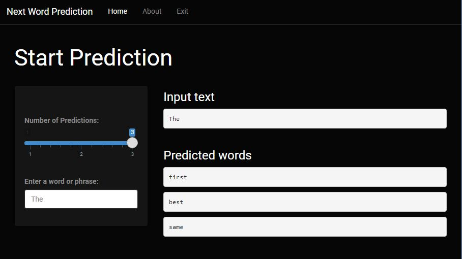